# ASM - Exercise week 11

Anne-Kathleen Malchow & Tobias Krüger

May 16, 2021

# 12H1

In 2014, a paper was published that was entitled “Female hurricanes are deadlier than male hurricanes.” As the title suggests, the paper claimed that hurricanes with female names have caused greater loss of life, and the explanation given is that people unconsciously rate female hurricanes as less dangerous and so are less likely to evacuate. Statisticians severely criticized the paper after publication. Here, you’ll explore the complete data used in the paper and consider the hypothesis that hurricanes with female names are deadlier.

Load the data:

```r
library(rethinking)
data(Hurricanes)
d <- Hurricanes
str(d)
```

```
## 'data.frame':    92 obs. of  8 variables:
##  $ name        : Factor w/ 83 levels "Able","Agnes",..: 38 77 1 9 47 20 40 60 27 33 ...
##  $ year        : int  1950 1950 1952 1953 1953 1954 1954 1954 1955 1955 ...
##  $ deaths      : int  2 4 3 1 0 60 20 20 0 200 ...
##  $ category    : int  3 3 1 1 1 3 3 4 3 1 ...
##  $ min_pressure: int  960 955 985 987 985 960 954 938 962 987 ...
##  $ damage_norm : int  1590 5350 150 58 15 19321 3230 24260 2030 14730 ...
##  $ female      : int  1 0 0 1 1 1 1 1 1 1 ...
##  $ femininity  : num  6.78 1.39 3.83 9.83 8.33 ...
```

Acquaint yourself with the columns by inspecting the help:

```r
?Hurricanes
```

```
## starting httpd help server ... done
```

In this problem, you’ll focus on predicting deaths using femininity of each hurricane’s name.

## Q:

1. Fit and interpret the simplest possible model, a Poisson model of deaths using femininity as a predictor. Compare the model to an intercept-only Poisson model of deaths.
2. How strong is the association between femininity of name and deaths?
3. Which storms does the model fit (retrodict) well? Which storms does it fit poorly?

## A:

### (1)

We compare two models:

$$\begin{align*}
\mathcal{M}_1: \,\, deaths_i &\sim {\sf Poisson}(\lambda_i) \\
{\sf log} \, \lambda_i &= \alpha + \beta \cdot femininity_i\\
\alpha &\sim {\sf Normal}(5, 0.5) \\
\beta &\sim {\sf Normal}(0, 0.05)
\end{align*}$$

$$\begin{align*}
\mathcal{M}_2: \,\, deaths_i &\sim {\sf Poisson}(\lambda_i) \\
{\sf log} \, \lambda_i &= \alpha \\
\alpha &\sim {\sf Normal}(5, 0.5)
\end{align*}$$

We chose the priors so as to represent the range of plausible results:

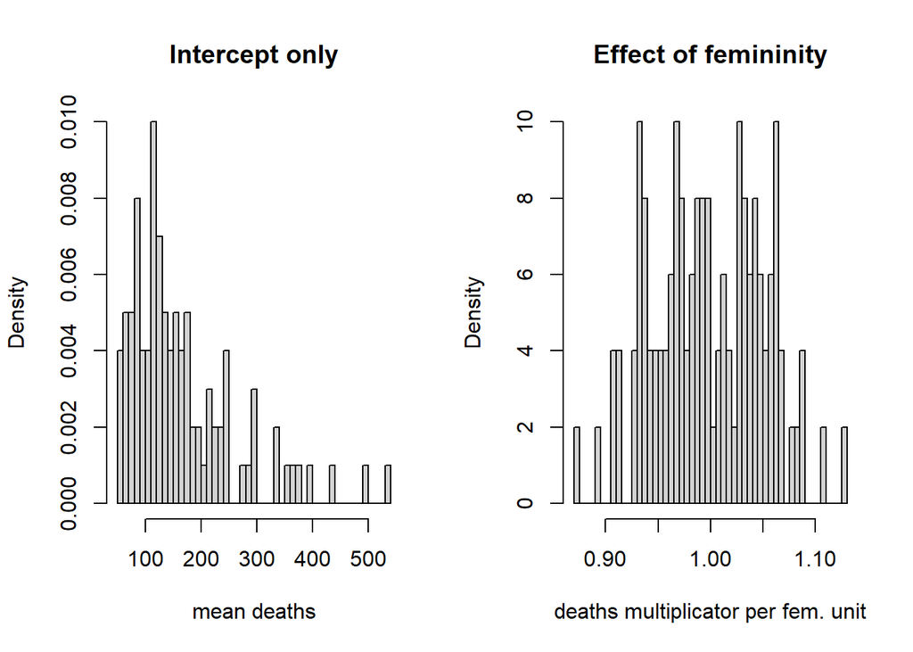

```r
N <- 100
alpha <- rnorm( N , 5 , .5 )
beta <- rnorm( N , 0 , .05 )
par(mfrow=c(1,2))
hist( exp(alpha) , 50, freq = FALSE, xlab = "mean deaths", main = "Intercept only")
hist( exp(beta) , 50, freq = FALSE, xlab = "deaths multiplicator per fem. unit", main = "Effect of femininity")
```

Together (prior predictive check):

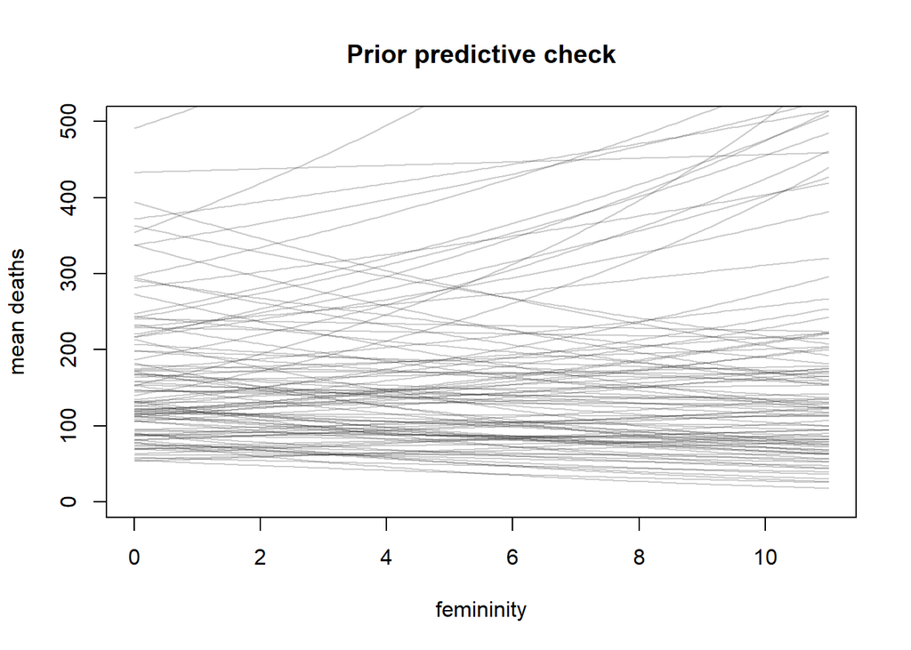

```r
plot( NULL , xlim=c(0,11) , ylim=c(0,500) , xlab = "femininity", ylab = "mean deaths", main = "Prior predictive check")
for ( i in 1:N ) curve( exp( alpha[i] + beta[i]*x ) , add=TRUE , col=rgb(0,0,0,.2) )
```

Fitting the models:

```r
library(brms)
library(ggplot2)
```

Use a Poisson likelihood with a log-link to the linear model:

```r
# M1
m.12H1.1 <-
  brm(data = subset(d, select=c('deaths','femininity')),
      # again, the log is the default link for the Poisson family, but shown here for clarity:
      family = poisson(link = "log"),
      formula = deaths ~ 1 + femininity,
      prior = c(prior(normal(5,.5), class = Intercept),
                prior(normal(0,.05), class = b)))

# M2
m.12H1.2 <-
  brm(data = subset(d, select=c('deaths','femininity')),
      family = poisson, # use default link
      formula = deaths ~ 1,
      prior = prior(normal(5,.5), class = Intercept))
```

Compute WAICs:

```r
m.12H1.1 <- add_criterion(m.12H1.1, "waic")
m.12H1.2 <- add_criterion(m.12H1.2, "waic")
```

```
## Warning:
## 13 (14.1%) p_waic estimates greater than 0.4. We recommend trying loo instead.
```

```r
loo_compare(m.12H1.1, m.12H1.2, criterion = "waic")
```

```
##          elpd_diff se_diff
## m.12H1.1   0.0       0.0
## m.12H1.2 -11.7      67.0
```

Follow warning message and compute PSIS-LOOs:

```r
m.12H1.1 <- add_criterion(m.12H1.1, "loo", reloo = TRUE)
m.12H1.2 <- add_criterion(m.12H1.2, "loo", reloo = TRUE)
loo_compare(m.12H1.1, m.12H1.2, criterion = "loo")
```

```
##          elpd_diff se_diff
## m.12H1.1   0.0       0.0
## m.12H1.2 -17.3      69.4
```

We find no meaningful difference in out-of-sample predictive performance of the two models. Including femininity of name into the model doesn’t give it more predictive power compared to an intercept-only model.

### (2)

Look at the effect per unit femininity of name on the number of deaths, on the log scale:

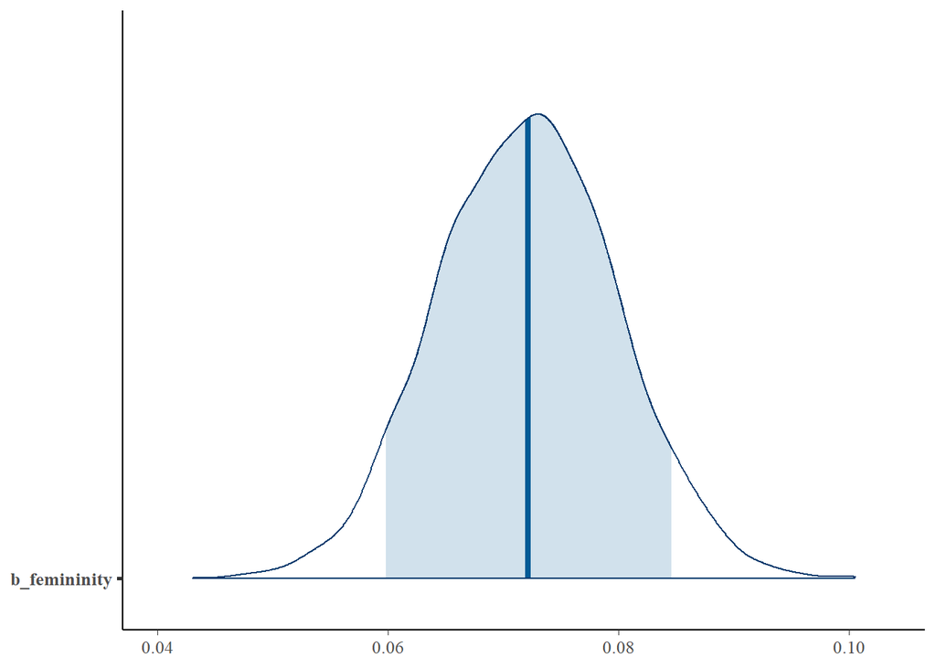

```r
mcmc_plot(m.12H1.1, type = "areas", pars = "b_femininity", prob = .89)
```

On the linear scale:

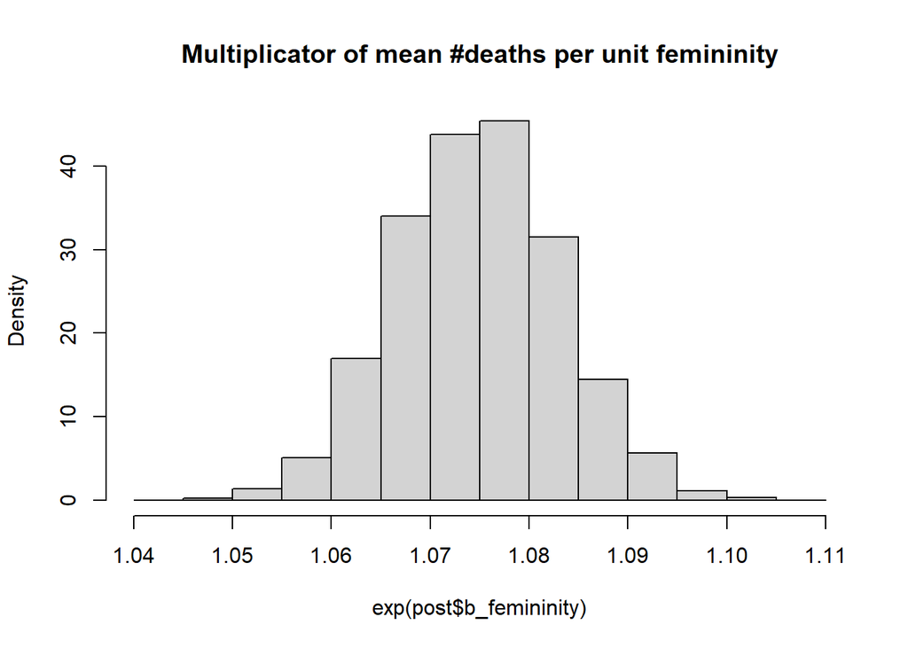

```r
post <- posterior_samples(m.12H1.1)
hist(exp(post$b_femininity), freq = FALSE, main = "Multiplicator of mean #deaths per unit femininity")
```

The femininity scale ranges from *0* to *11*. For each unit of femininity the mean death count is multiplied by $exp(\beta)$. The posterior of $\beta$ (resp. *b_femininity*) is entirely above *0*, so that $exp(\beta)>1$, consistently. This means, the mean death count increases with each unit of femininity.

### (3)

Plot the data along with the *89%* compatibility intervals, both mean response and actual response:

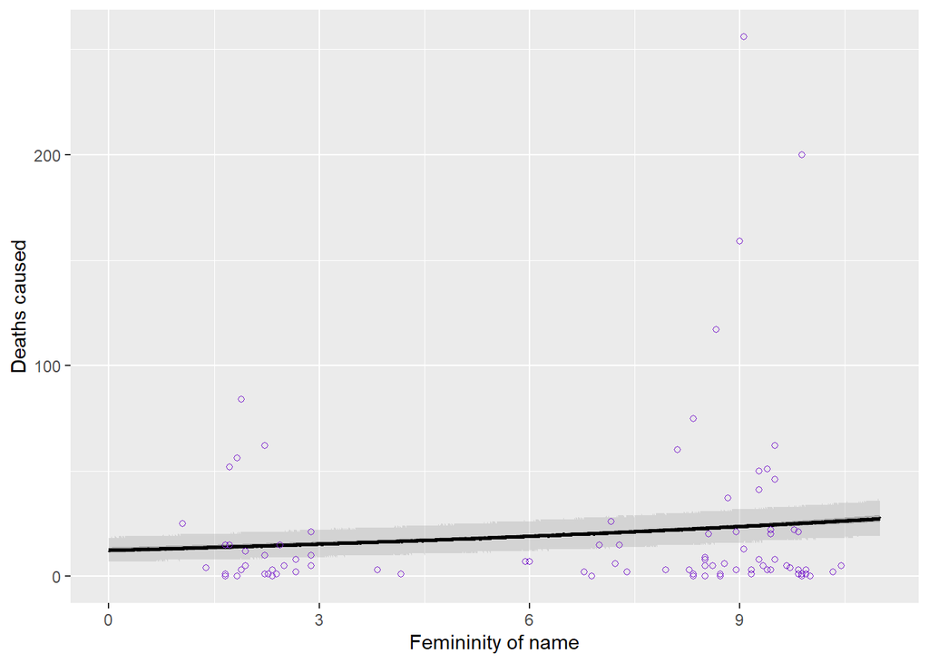

```r
x <- seq(0,11,length.out=1000)
pred <- predict(m.12H1.1, newdata = data.frame(femininity=x), probs = c(.055,.945))
fitd <-  fitted(m.12H1.1, newdata = data.frame(femininity=x), probs = c(.055,.945))

df <- cbind(x, fitd[,-2], pred[,-2])
colnames(df)[2:4] <- paste0("fit_",colnames(df)[2:4])
colnames(df)[5:7] <- paste0("prd_",colnames(df)[5:7])

p <- ggplot(data = data.frame(df), aes(x = x)) +
      geom_smooth(aes(y = prd_Estimate, ymin = prd_Q5.5, ymax = prd_Q94.5),
              stat = "identity",
              color = "black",
              alpha = .3) +
      geom_smooth(aes(y = fit_Estimate, ymin = fit_Q5.5, ymax = fit_Q94.5),
              stat = "identity",
              color = "black",
              alpha = .7) +
      geom_point(data = d,
                 aes(x = femininity,
                     y = deaths),
                 color = "purple3", shape = 1, size = 1.5) +
  ylab("Deaths caused") +
  xlab("Femininity of name")
p
```

The model doesn’t seem to capture the data very well.

In addition, the *89%* compatibility intervals are extremely narrow. We have to zoom in to see better:

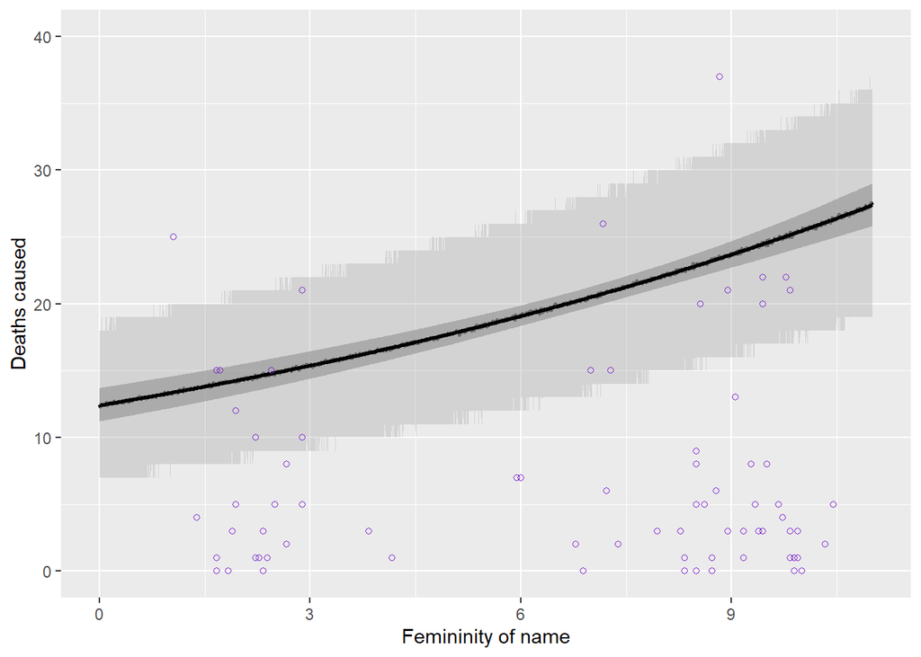

```r
p + scale_y_continuous("Deaths caused", limits = c(0,40))
```

Using the built-in posterior check functionality in `brms`, imported from the `bayesplot` package: (There are many different plot types available, check out the help page `?'PPC-overview'` and try various options!)

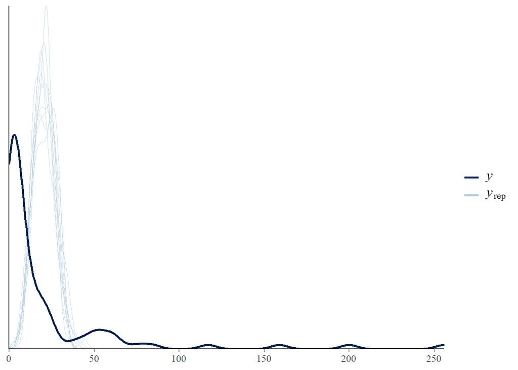

```r
pp_check(m.12H1.1, type = "dens_overlay")
```

This plot shows the ‘density distribution’ (read ‘smoothed histogram’) of the observed data *y* as a thick black line, overlaid with a number of simulated densities / histograms *y_rep* of the same sample size. That is, each of the thin lines represents a set of parameters drawn from the posterior, which is then used to generate a simulated data set.

In relation to the deaths~femininity plot above, this can be seen as the projection of the x-axis onto the y-axis. The probability density of the fitted model concentrates tightly around its mean, while the actual observed data is more spread out and at the same time has its density maximum at a lower value. We say, the data are ‘over-dispersed’ with respect to the Poisson model: The Poisson model with it’s dispersion increasing with the mean cannot capture the very right-skewed distribution of the data. Hence we look at a better model next.

# 12H2

## Q:

Counts are nearly always over-dispersed relative to Poisson. So fit a gamma-Poisson (aka negative-binomial) model to predict deaths using femininity. Show that the over-dispersed model no longer shows as precise a positive association between femininity and deaths, with an *89%* interval that overlaps zero. Can you explain why the association diminished in strength?

## A:

Compare a third, ‘over-dispersed’ model:

$$\begin{align*}
\mathcal{M}_3: \,\, deaths_i &\sim {\sf NegBinomial}(\lambda_i, \phi) \\
{\sf log} \, \lambda_i &= \alpha + \beta \cdot femininity_i\\
\alpha &\sim {\sf Normal}(5, 0.5) \\
\beta &\sim {\sf Normal}(0, 0.05) \\
\phi &\sim {\sf Exponential}(1)
\end{align*}$$

We use the priors from above plus the exponential prior for the shape parameter as used in the book.

```r
# M3
m.12H1.3 <-
  brm(data = subset(d, select=c('deaths','femininity')),
      family = negbinomial(link = "log"),
      formula = deaths ~ 1 + femininity,
      prior = c(prior(normal(5,.5), class = Intercept),
                prior(normal(0,.05), class = b),
                prior(exponential(1), class = shape)))
```

```r
summary(m.12H1.3)
```

```
##  Family: negbinomial
##   Links: mu = log; shape = identity
## Formula: deaths ~ 1 + femininity
##    Data: subset(d, select = c("deaths", "femininity")) (Number of observations: 92)
## Samples: 4 chains, each with iter = 2000; warmup = 1000; thin = 1;
##          total post-warmup samples = 4000
##
## Population-Level Effects:
##            Estimate Est.Error l-95% CI u-95% CI Rhat Bulk_ESS Tail_ESS
## Intercept      3.01      0.32     2.39     3.63 1.00     3480     3022
## femininity     0.03      0.04    -0.04     0.11 1.00     3776     3296
##
## Family Specific Parameters:
##       Estimate Est.Error l-95% CI u-95% CI Rhat Bulk_ESS Tail_ESS
## shape     0.45      0.06     0.34     0.58 1.00     3643     3055
##
## Samples were drawn using sampling(NUTS). For each parameter, Bulk_ESS
## and Tail_ESS are effective sample size measures, and Rhat is the potential
## scale reduction factor on split chains (at convergence, Rhat = 1).
```

With the new, over-dispersed model, let’s look again at the effect per unit femininity of name on the number of deaths:

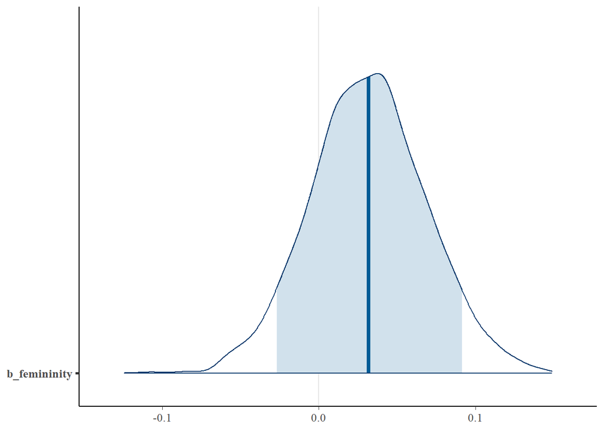

```r
mcmc_plot(m.12H1.3, type = "areas", pars = "b_femininity", prob = .89)
```

The *89%* interval now overlaps quite a lot with zero. Thus, there is no clear association between femininity and deaths in this model.

The negative binomial distribution allows for a larger variance than just the Poisson. As we have seen above, the data clearly show more variance than the Poisson model can accommodate. Instead, the Poisson model was ‘trying’ to explain the variance with the only predictor, `femininity`. The gamma-Poisson, on the other hand, can adjust to this high variance regardless and thus results in no clear effect of `femininity`.

For completeness, we do another posterior predictive check with the new model:

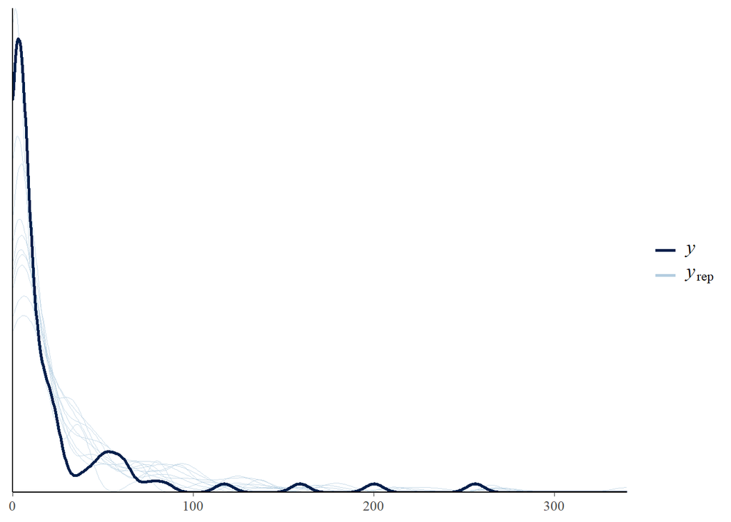

```r
pp_check(m.12H1.3)
```

In fact, the gamma-Poisson model is capable of reproducing the observed data much better.